# Heatmaps with Package Seriation

Michael Hahsler

# Introduction

A [Heatmap](https://en.wikipedia.org/wiki/Heat_map) uses colored tiles to represent the values in a data matrix. Patterns can be easily seen if the rows and columns are appropriately reordered. There are many ways to reorder a matrix, and the order has a significant impact on the visualization’s usefulness. The package `seriation` implements a large number of reordering methods (see: the [list with all implemented seriation methods](https://michael.hahsler.net/seriation/articles/seriation_methods.html)). `seriation` also provides a set of functions to display reordered heatmaps:

- `pimage()`
- `hmap()`
- `gghmap()`

How to cite the `seriation` package:

> Hahsler M, Hornik K, Buchta C (2008). “Getting things in order: An introduction to the R package seriation.” *Journal of Statistical Software*, *25*(3), 1-34. ISSN 1548-7660, doi:10.18637/jss.v025.i03 https://doi.org/10.18637/jss.v025.i03.

## Prepare the data

As an example, we use the `Wood` dataset with the normalized gene expression data (a sample of 136 genes) for wood formation in poplar trees in 6 locations. In case the data already has some order, we randomly reorder rows and columns for this example.

```r
library("seriation")
data("Wood")
Wood <- Wood[sample(nrow(Wood)), sample(ncol(Wood))]
dim(Wood)
```

```
## [1] 136   6
```

```r
DT::datatable(round(Wood, 2))
```

|  | E | A | B | P | C | D |
| --- | --- | --- | --- | --- | --- | --- |
| AI161674 | -0.87 | -2.52 | -2.41 | -2.14 | -0.51 | 1.31 |
| AI164370 | -2.06 | 0.04 | -0.18 | -1.65 | 0.23 | 0.4 |
| AI165062 | -0.04 | -1.75 | -1.05 | -2.01 | 0.59 | 0.82 |
| AI165868 | -1.32 | -2.84 | -2.29 | -2.03 | -0.07 | 1.05 |
| AI165247 | -0.85 | -2.16 | -1.38 | -1.52 | 0.71 | 1.07 |
| AI163485 | -2.1 | 1.19 | 0.11 | -0.21 | -1.48 | -3.06 |
| AI162652 | -2.51 | 0.99 | 0.4 | 0.84 | -0.21 | -1.88 |
| AI161452 | 0.88 | -2.24 | -2.42 | -0.75 | -0.82 | 1.01 |
| AI163594 | 1.46 | -2.19 | -2.14 | -1.85 | -0.78 | 0.74 |
| AI164964 | 0.87 | -1.17 | -0.78 | -2.08 | 0.31 | 0.75 |

[output cut: 126 more lines]

Here is a simple heatmap without reordering. No structure is visible.

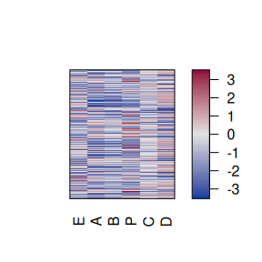

```r
pimage(Wood)
```

## Reordering in seriation

Many seriation methods are available. The [manual page for seriate()](https://mhahsler.r-universe.dev/seriation/doc/manual.html#seriate) describes the methods available in package `seriation`.

Methods of interest for heatmaps are dendrogram leaf order-based methods applied to rows and columns. This is done using `method = "heatmap"`. The actual seriation method can be passed on as parameter `seriation_method`, but it has a suitable default if it is omitted. Here is an example:

```r
o <- seriate(Wood, method = "Heatmap", seriation_method = "HC_Mean")
o
```

```
## object of class 'ser_permutation', 'list'
## contains permutation vectors for 2-mode data
##
##   vector length seriation method
## 1           136          Heatmap
## 2             6          Heatmap
```

This is the order for rows and columns. The method `heatmap` automatically performs hierarchical clustering and then applies the seriation method for reordering of dendrogram leaves. Here we use the row/column mean to reorder the dendrogram. The resulting order (2 means second dimension, i.e., columns) can be shown, and the reordered dendrogram and a reordered image can be plotted.

```r
get_order(o, 2)
```

```
## B A P E C D
## 3 2 4 1 5 6
```

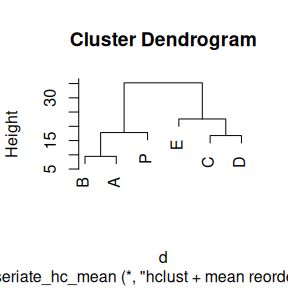

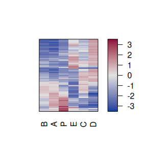

```r
plot(o[[2]])
pimage(Wood, order = o)
```

# Built-in heatmap function

Package `seriation` has several functions to display heatmaps.

## Without dendrograms: pimage

The permutation image plot in `seriation` provides a simple heatmap. The order argument not only accepts a seriation order, but also a seriation method.

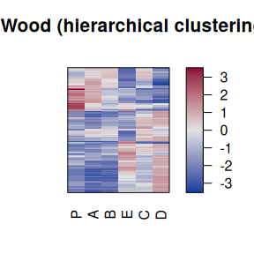

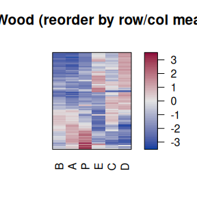

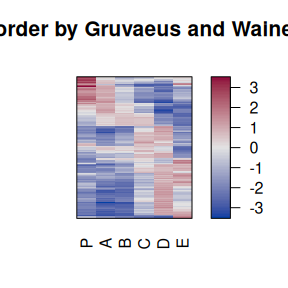

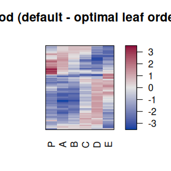

```r
pimage(Wood, order = "Heatmap", seriation_method = "HC_complete",
       main = "Wood (hierarchical clustering)")
pimage(Wood, order = "Heatmap", seriation_method = "HC_Mean",
       main = "Wood (reorder by row/col mean)")
pimage(Wood, order = "Heatmap", seriation_method = "GW_complete",
       main = "Wood (reorder by Gruvaeus and Wainer heuristic)")
pimage(Wood, order = "Heatmap",
       main = "Wood (default - optimal leaf ordering)")
```

## With dendrograms: hmap

Here are some typical reordering schemes.

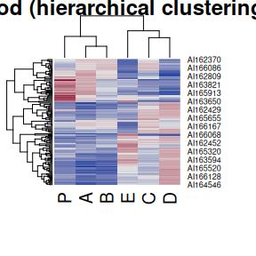

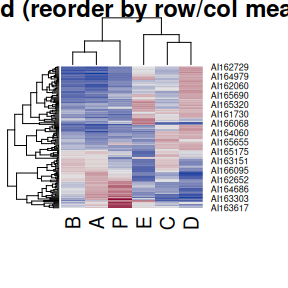

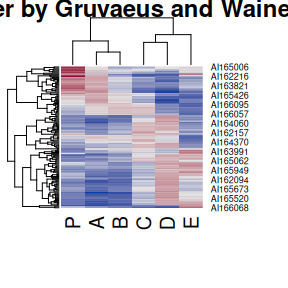

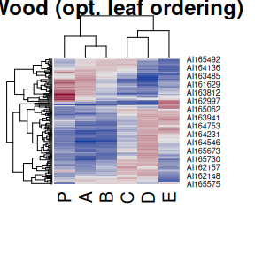

```r
hmap(Wood, method = "HC_complete", main = "Wood (hierarchical clustering)")
hmap(Wood, method = "HC_Mean", main = "Wood (reorder by row/col mean)")
hmap(Wood, method = "GW_complete", main = "Wood (reorder by Gruvaeus and Wainer heuristic)")
hmap(Wood, method = "OLO_complete", main = "Wood (opt. leaf ordering)")
```

Different linkage types can be added in the method name.

Package `DendSer` offers more dendrogram seriation methods. These methods can be registered using `register_DendSer()``

```r
register_DendSer()
```

```
## Registering new seriation method 'DendSer' for 'dist' requested by register_DendSer()
```

```
## Registering new seriation method 'DendSer_BAR' for 'dist' requested by register_DendSer()
```

```
## Registering new seriation method 'DendSer_PL' for 'dist' requested by register_DendSer()
```

```
## Registering new seriation method 'DendSer_LPL' for 'dist' requested by register_DendSer()
```

```
## Registering new seriation method 'DendSer_ARc' for 'dist' requested by register_DendSer()
```

```
## Registering new seriation criterion 'ARc' for 'dist' using register_DendSer()
```

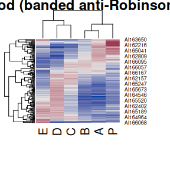

```r
hmap(Wood, method = "DendSer_BAR", main = "Wood (banded anti-Robinson)")
```

## With distance matrices instead of dendrograms: hmap

Instead of dendrograms, also reordered distance matrices can be displayed. Dark block around the diagonal indicate the cluster structure.

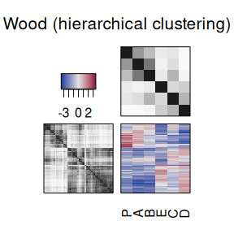

```r
hmap(Wood, method = "HC_complete",
     plot_margins = "distances",
     main = "Wood (hierarchical clustering)")
```

Also non-dendrogram-based reordering methods can be used. These methods reorder rows and columns. Instead of the dendrograms, reordered distance matrices are shown.

[figure not shown]

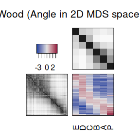

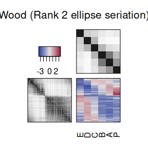

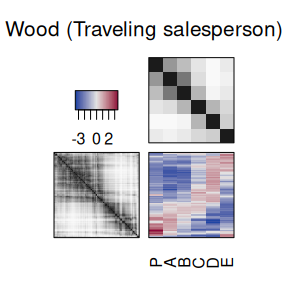

```r
hmap(Wood, method = "MDS", main = "Wood (MDS)")
hmap(Wood, method = "MDS_angle", main = "Wood (Angle in 2D MDS space)")
hmap(Wood, method = "R2E", main = "Wood (Rank 2 ellipse seriation)")
hmap(Wood, method = "TSP", main = "Wood (Traveling salesperson)")
```

## colors with pimage and hmap

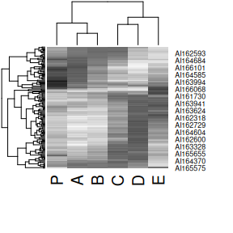

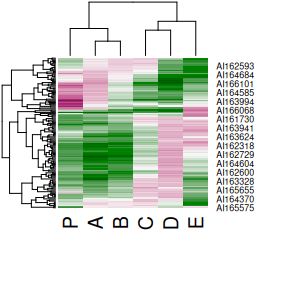

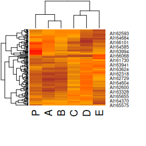

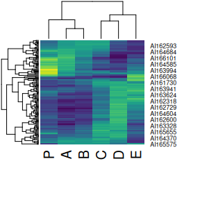

```r
hmap(Wood, col = grays())
hmap(Wood, col = greenred())

hmap(Wood, col = colorRampPalette(c("brown", "orange", "red"))( 100 ) )

hmap(Wood, col = viridis::viridis(100))
```

There are many other packages to create color palettes in R like `RColorBrewer` or `colorspaces`.

## ggplot2

All options are also available for `ggplot2` using `gghmap()`. Currently there is no support to display dendrograms.

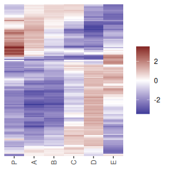

```r
if (!require("ggplot2")) install.packages("ggplot2")

library(ggplot2)
gghmap(Wood, method = "OLO")
```

# Using seriation with other packages

The package `seriation` can be used to compute reordering for other heatmap packages.

## heatmap in package stats

This is R’s standard heatmap function. `seriate()` can be used to supply the reordered dendrogram.

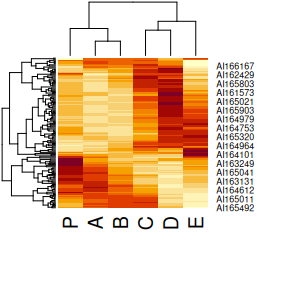

```r
o <- seriate(Wood, method = "Heatmap", seriation_method = "OLO")
heatmap(Wood, Rowv = as.dendrogram(o[[1]]), Colv = as.dendrogram(o[[2]]))
```

We can also supply the rank order for any seriation method as weights and the dendrogram will be reordered as close as possible to the seriation order.

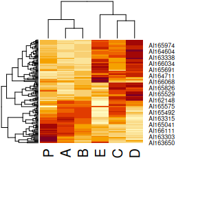

```r
o <- seriate(Wood, method = "Heatmap", seriation_method = "Spectral")
heatmap(Wood, Rowv =  get_rank(o, 1), Colv =  get_rank(o, 2))
```

## Package heatmaply

The package creates interactive heatmaps. It already uses the package `seriation` for parameter `seriate` and supports the `OLO` and `GW` methods.

```r
if (!suppressMessages(require("heatmaply"))) install.packages("heatmaply")

library("heatmaply")
heatmaply(Wood, seriate = "none", main = "HC")
```

[interactive chart not shown]

```r
heatmaply(Wood, seriate = "OLO", main = "OLO")
```

[interactive chart not shown]

Any dendrogram-based seriation method from `seriation` can be supplied.

```r
o <- seriate(Wood, method = "Heatmap", seriation_method = "OLO_ward")
heatmaply(Wood, Rowv = o[[1]], Colv = o[[2]], main = "OLO (Ward)")
```

[interactive chart not shown]

```r
o <- seriate(Wood, method = "Heatmap", seriation_method = "Spectral")
heatmaply(Wood, Rowv = get_rank(o, 1), Colv = get_rank(o, 2), main = "Spectral")
```

[interactive chart not shown]